# Untitled

hyo

2020 4 3

##### 문제1

- 다음 데이터를 벡터 x에 다음 숫자열이 입력되어 있다
- 1. 벡터 x의 값중 20 이상인 것만 출력하라.
- 2. 벡터 x의 값중 20 이상인 숫자를 100으로 바꾸어 y로 저장하여라.

```r
x=c(17, 16, 20, 24, 22, 15, 21, 18)
x
```

```
## [1] 17 16 20 24 22 15 21 18
```

```r
#1.(1)
x[which(x>=20)]
```

```
## [1] 20 24 22 21
```

```r
#1.(2)
x[which(x>=20)]=100
y = x
y
```

```
## [1]  17  16 100 100 100  15 100  18
```

##### 문제2

- 1부터 100까지 짝수로 이루어진 숫자만을 x에 벡터로 저장하시오

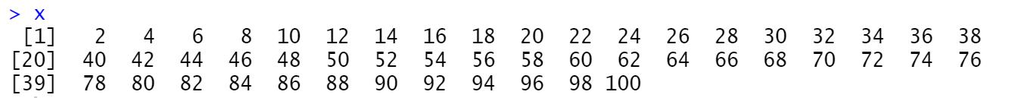

```r
x = seq(2,100,2)
x
```

```
##  [1]   2   4   6   8  10  12  14  16  18  20  22  24  26  28  30  32  34  36  38
## [20]  40  42  44  46  48  50  52  54  56  58  60  62  64  66  68  70  72  74  76
## [39]  78  80  82  84  86  88  90  92  94  96  98 100
```

##### 문제3

- for문을 활용하여 1~1000까지의 합을 구하시오

```r
sum1000 = 0
for(n in 1:1000){
 sum1000 = sum1000 + n
}
sum1000
```

```
## [1] 500500
```

##### 문제4

```r
coin = function(n){ #n : 동전 던진 횟수
    cnt = 0
    for(i in 1:x){
        p = round(runif(1,0,1))
        if(p == 1){ #1: 앞면
            cnt = cnt+1
        }
    }
    return(cnt/x)
}
coin(8)
```

```
##  [1] 0.50000000 0.25000000 0.16666667 0.12500000 0.10000000 0.08333333
##  [7] 0.07142857 0.06250000 0.05555556 0.05000000 0.04545455 0.04166667
## [13] 0.03846154 0.03571429 0.03333333 0.03125000 0.02941176 0.02777778
## [19] 0.02631579 0.02500000 0.02380952 0.02272727 0.02173913 0.02083333
## [25] 0.02000000 0.01923077 0.01851852 0.01785714 0.01724138 0.01666667
## [31] 0.01612903 0.01562500 0.01515152 0.01470588 0.01428571 0.01388889
## [37] 0.01351351 0.01315789 0.01282051 0.01250000 0.01219512 0.01190476
## [43] 0.01162791 0.01136364 0.01111111 0.01086957 0.01063830 0.01041667
## [49] 0.01020408 0.01000000
```

##### 문제5

- 원주율을 구하는 공식은 다음과 같다.
- 아래 공식과 for문을 활용하여 원주율을 계산하는 함수를 만드시오

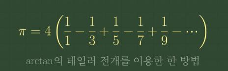

```r
x = 1000000
pi = 0
for(i in 1:x){
   if(i%%2 == 1){
      pi = pi + 4/(2*i-1)
   }
   else{
      pi = pi - 4/(2*i-1)
   }
}
pi
```

```
## [1] 3.141592
```

##### 문제6

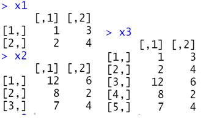

```r
x1 = matrix(c(1,2,3,4),2,2)
x2 = matrix(c(12,8,7,6,2,4),3,2)
x3 = rbind(x1,x2)
```

##### 문제7

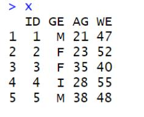

```r
gen = c("M","F","F","I","M")
id = c(1,2,3,4,5)
age = c(21,23,35,28,38)
weight = c(47,52,40,55,48)
x =data.frame(ID=id,GE=gen,AG=age,WE=weight)

#1)
x$GE = ifelse(x$GE=="M",1,ifelse(x$GE=="F",2,3))
#2)
x[x$AG>=20&x$AG<30&x$GE==2,]
```

```
##   ID GE AG WE
## 2  2  2 23 52
```

```r
#3)
mean(x[x$GE=="M",3])
```

```
## [1] NaN
```

##### 문제8

- X = c(“qweerf=-123adklad”, “dklaj456asddfg”)
  - 위 벡터에서 숫자만을 추출하시오(gsub 활용)
  - `^`를 안에다가 사용할 결우 not의 의미가 된다

```r
X = c("qweerf=-123adklad", "dklaj456asddfg")
gsub("[^0-9]","",X)
```

```
## [1] "123" "456"
```

##### 문제9

- 아래의 a,b벡터를 만들고
  - Paste를 활용하여 c를 만들어보시오

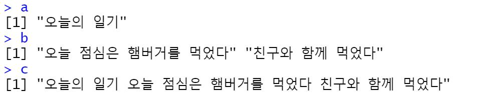

```r
a = "오늘의 일기"
b = c("오늘 점심은 햄버거를 먹었다", "친구와 함께 먹었다")

c = paste(a,paste(b,collapse = " "),collapse = " ")
```

##### 문제10

- x = “adefa”가 주어졌을때 ’a’들의 위치를 출력하는 함수를 만드시오
  - (nchar, substr 사용)

```r
x = "adefa"
f = function(x){
    for(i in 1:nchar(x)){
        if(substr(x,i,i)=="a"){
            print(i)        }
    }
}
f(x)
```

```
## [1] 1
## [1] 5
```